# Ex34 insecticida

PIE2

Tardor 2019-2020

#### 2. En un estudi s’ha provat l’efectivitat de diferents dosis d’un insecticida. Les variables són: la dosi de l’insecticida, DOSI, el nombre d’insectes al que s’ha aplicat una dosi d’insecticida, T, i el nombre d’insectes que han mort amb l’insecticida, MORTS.

#### Els resultats de mortalitat obtinguts són al fitxer “insecticida.csv”. Amb $\alpha=0.05$:

*Entrar dades, paquests, descriptiva…*

```r
#setwd("...")
dd<-read.csv2("../data/insecticida.csv")
library(car)
library(RcmdrMisc)
head(dd)
```

```
##    DOSI  T MORTS
## 1  0.75 90     0
## 2  1.50 80     2
## 3  3.00 90     4
## 4  6.00 60    13
## 5  7.50 85    27
## 6 10.00 60    32
```

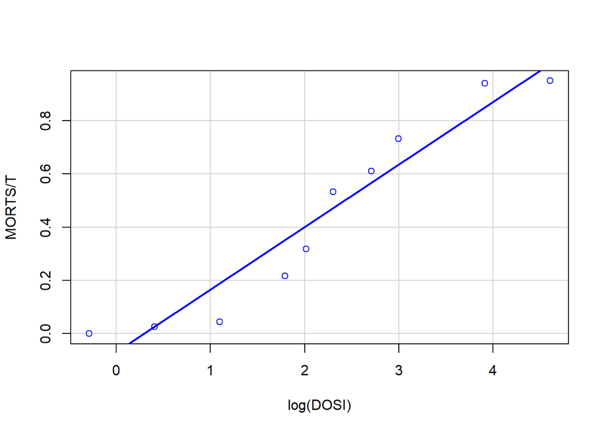

```r
scatterplot(MORTS/T~log(DOSI),smooth=F,boxplots=F,data=dd)
```

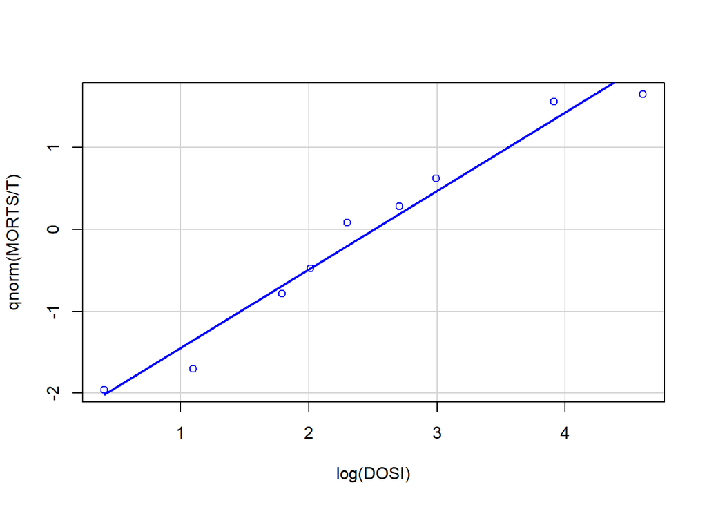

```r
scatterplot(qnorm(MORTS/T)~log(DOSI),smooth=F,boxplots=F,data=dd[2:10,])
```

**a) Proposeu un model lineal generalitzat en el que la probabilitat de morir** $\pi$**, depengui de la dosi seguint la funció** $\pi=\Phi\left(\beta_{0}+\beta_{1}\cdot log\left(DOSI\right)\right)$**, on** $\Phi$ **és la funció de distribució d’una N(0,1).**

*i. Estimeu* $\beta_{0}$ *i* $\beta_{1}$*.* $\beta_{0}=0?$*,* $\beta_{1}=0?$

```r
summary(m1<-glm(cbind(MORTS,T-MORTS)~log(DOSI),family=binomial(link="probit"),data=dd))
```

```
##
## Call:
## glm(formula = cbind(MORTS, T - MORTS) ~ log(DOSI), family = binomial(link = "probit"),
##     data = dd)
##
## Deviance Residuals:
##      Min        1Q    Median        3Q       Max
## -1.64307  -0.57945  -0.00249   0.26904   1.49615
##
## Coefficients:
##             Estimate Std. Error z value Pr(>|z|)
## (Intercept) -2.57057    0.18524  -13.88   <2e-16 ***
## log(DOSI)    1.04756    0.07689   13.62   <2e-16 ***
## ---
## Signif. codes:  0 '***' 0.001 '**' 0.01 '*' 0.05 '.' 0.1 ' ' 1
##
## (Dispersion parameter for binomial family taken to be 1)
##
##     Null deviance: 398.5646  on 9  degrees of freedom
## Residual deviance:   7.6834  on 8  degrees of freedom
## AIC: 45.684
##
## Number of Fisher Scoring iterations: 4
```

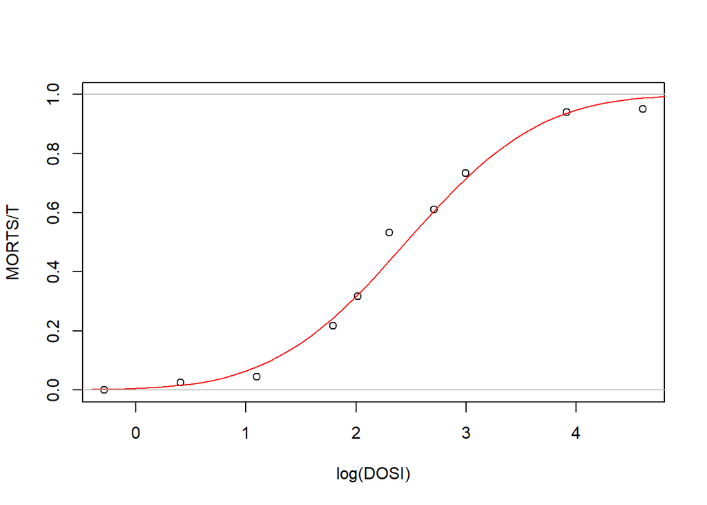

```r
#dosis<-0:100+.5
dosis<-exp(seq(-1,5,.1))
plot(MORTS/T~log(DOSI),dd,ylim=c(0,1))
lines(predict(m1,data.frame(DOSI=dosis),ty="response")~log(dosis),col="red")
abline(h=c(0,1),col="grey")
```

Predicció link feta a mà

```r
(X<-cbind(1,log(dd$DOSI)))
```

```
##       [,1]       [,2]
##  [1,]    1 -0.2876821
##  [2,]    1  0.4054651
##  [3,]    1  1.0986123
##  [4,]    1  1.7917595
##  [5,]    1  2.0149030
##  [6,]    1  2.3025851
##  [7,]    1  2.7080502
##  [8,]    1  2.9957323
##  [9,]    1  3.9120230
## [10,]    1  4.6051702
```

```r
(beta<-m1$coefficients)
```

```
## (Intercept)   log(DOSI)
##   -2.570569    1.047560
```

```r
t(pl<-X%*%beta)
```

```
##           [,1]     [,2]      [,3]       [,4]       [,5]       [,6]
## [1,] -2.871933 -2.14582 -1.419706 -0.6935929 -0.4598366 -0.1584723
##           [,7]      [,8]     [,9]    [,10]
## [1,] 0.2662769 0.5676412 1.527511 2.253624
```

```r
predict(m1)
```

```
##          1          2          3          4          5          6
## -2.8719332 -2.1458198 -1.4197063 -0.6935929 -0.4598366 -0.1584723
##          7          8          9         10
##  0.2662769  0.5676412  1.5275110  2.2536244
```

Predicció resposta feta a mà.

La inversa del link és $\pi=\Phi\left(\beta_{0}+\beta_{1}\cdot log\left(DOSI\right)\right)$, on $\Phi$ és la funció de distribució d’una N(0,1).

```r
t(pr<-pnorm(pl))
```

```
##             [,1]       [,2]      [,3]      [,4]      [,5]      [,6]
## [1,] 0.002039846 0.01594368 0.0778466 0.2439688 0.3228168 0.4370423
##          [,7]      [,8]     [,9]     [,10]
## [1,] 0.604987 0.7148607 0.936683 0.9878901
```

```r
predict(m1,ty="response")
```

```
##           1           2           3           4           5           6
## 0.002039846 0.015943681 0.077846599 0.243968781 0.322816770 0.437042342
##           7           8           9          10
## 0.604987013 0.714860685 0.936682998 0.987890097
```

Càlcul de la deviància a mà $2\sum_{i=1}^{N}\left(y_{i}\log\left(\frac{y_{i}}{\hat{\mu}_{i}}\right)+\left(m_{i}-y_{i}\right)\log\left(\frac{m_{i}-y_{i}}{m_{i}-\hat{\mu}_{i}}\right)\right)$

```r
t(pmu<-pr*dd$T)
```

```
##           [,1]     [,2]     [,3]     [,4]     [,5]     [,6]     [,7]
## [1,] 0.1835861 1.275494 7.006194 14.63813 27.43943 26.22254 54.44883
##          [,8]     [,9]   [,10]
## [1,] 42.89164 46.83415 39.5156
```

```r
(dev<-2*sum(ifelse(dd$MORTS==0,0,dd$MORTS*log(dd$MORTS/pmu))+(dd$T-dd$MORTS)*log((dd$T-dd$MORTS)/(dd$T-pmu))))
```

```
## [1] 7.683437
```

```r
m1$deviance
```

```
## [1] 7.683437
```

Residus de Pearson

```r
t((dd$MORTS-pmu)/sqrt(dd$T*pr*(1-pr)))
```

```
##            [,1]      [,2]      [,3]       [,4]     [,5]     [,6]     [,7]
## [1,] -0.4289072 0.6466845 -1.182699 -0.4924191 -0.10194 1.503702 0.118846
##           [,8]       [,9]     [,10]
## [1,] 0.3169316 0.09631065 -2.190943
```

```r
resid(m1,ty="pearson")
```

```
##           1           2           3           4           5           6
## -0.42890720  0.64668451 -1.18269925 -0.49241913 -0.10193999  1.50370159
##           7           8           9          10
##  0.11884603  0.31693159  0.09631065 -2.19094286
```

Residus deviance

```r
t(sign(dd$MORTS-pmu)*sqrt(2*(ifelse(dd$MORTS==0,0,dd$MORTS*log(dd$MORTS/pmu))+(dd$T-dd$MORTS)*log((dd$T-dd$MORTS)/(dd$T-pmu)))))
```

```
##            [,1]      [,2]      [,3]       [,4]       [,5]    [,6]
## [1,] -0.6062568 0.5974364 -1.279056 -0.4990249 -0.1020839 1.49615
##           [,7]      [,8]       [,9]    [,10]
## [1,] 0.1189544 0.3190689 0.09711268 -1.64307
```

```r
resid(m1,ty="deviance")
```

```
##           1           2           3           4           5           6
## -0.60625676  0.59743637 -1.27905610 -0.49902488 -0.10208392  1.49614961
##           7           8           9          10
##  0.11895441  0.31906888  0.09711268 -1.64306971
```

*ii. Mitjançant l’estadístic de Pearson, calculeu el paràmetre de dispersió. Penseu que pot haver-hi sobredispersió?*

```r
c("Pearson"=PS1<-sum(residuals(m1,type="pearson")^2),"G.L."=m1$df.res)
```

```
##  Pearson     G.L.
## 9.439003 8.000000
```

```r
c("Par.disp"=PS1/m1$df.res,"p.valor"=2*min(pchisq(PS1,m1$df.res),1-pchisq(PS1,m1$df.res)))
```

```
##  Par.disp   p.valor
## 1.1798754 0.6132504
```

*No es detecta si sobre ni sub-dispersió.*

*iii. Amb la gràfica de residuals front predits, dieu si us sembla que la funció ajusta bé.*

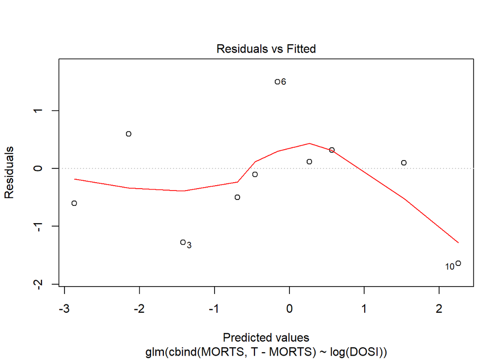

```r
plot(m1,1)
```

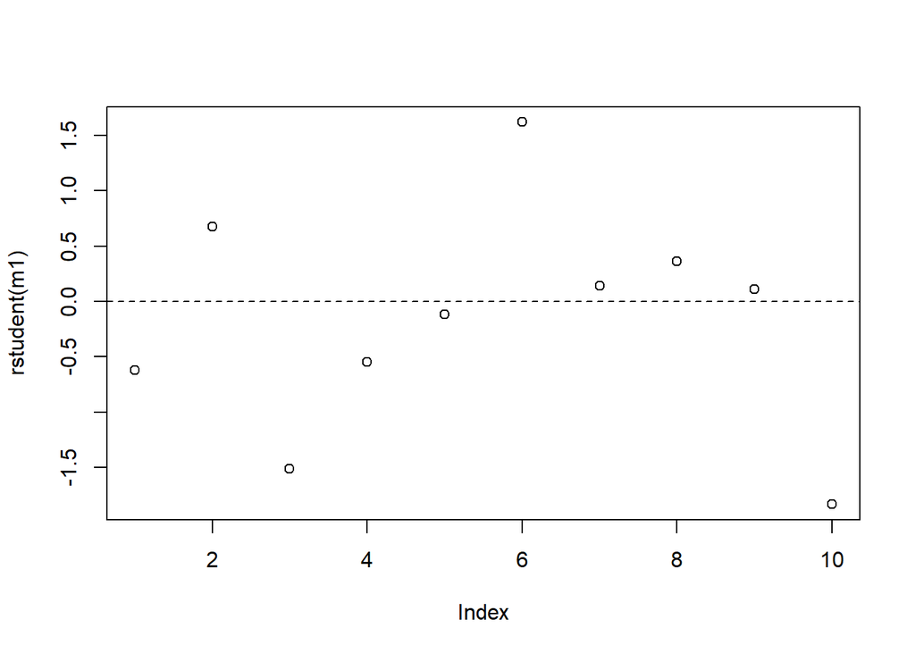

```r
plot(rstudent(m1))
abline(h=c(-2,0,2),lt=2)
```

**b) Proposeu un model lineal generalitzat en el que la probabilitat de morir** $\pi$**, depengui de la dosi seguint la funció** $\pi=\frac{1}{1+a\cdot DOSI^{b}}.$

*i. Estimeu* $\beta_{0}$ *i* $\beta_{1}$*.* $\beta_{0}=0?$*,* $\beta_{1}=0?$

```r
summary(m2<-glm(cbind(MORTS,T-MORTS)~log(DOSI),family=binomial(link="logit"),data=dd))
```

```
##
## Call:
## glm(formula = cbind(MORTS, T - MORTS) ~ log(DOSI), family = binomial(link = "logit"),
##     data = dd)
##
## Deviance Residuals:
##     Min       1Q   Median       3Q      Max
## -1.3457  -0.8288  -0.1668   0.1066   1.5159
##
## Coefficients:
##             Estimate Std. Error z value Pr(>|z|)
## (Intercept)  -4.6081     0.3707  -12.43   <2e-16 ***
## log(DOSI)     1.8891     0.1542   12.25   <2e-16 ***
## ---
## Signif. codes:  0 '***' 0.001 '**' 0.01 '*' 0.05 '.' 0.1 ' ' 1
##
## (Dispersion parameter for binomial family taken to be 1)
##
##     Null deviance: 398.5646  on 9  degrees of freedom
## Residual deviance:   6.6528  on 8  degrees of freedom
## AIC: 44.654
##
## Number of Fisher Scoring iterations: 4
```

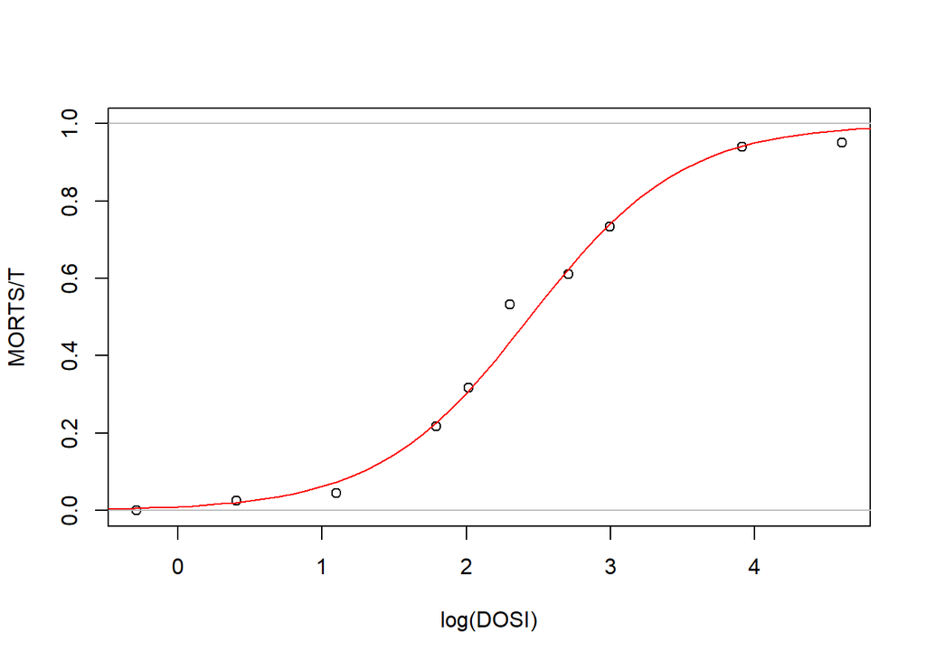

```r
plot(MORTS/T~log(DOSI),dd,ylim=c(0,1))
lines(predict(m2,data.frame(DOSI=dosis),ty="response")~log(dosis),col="red")
abline(h=c(0,1),col="grey")
```

*ii. Mitjançant l’estadístic de Pearson, calculeu el paràmetre de dispersió. Penseu que pot haver-hi sobredispersió?*

```r
c("Pearson"=PS2<-sum(residuals(m2,type="pearson")^2),"G.L."=m2$df.res)
```

```
##  Pearson     G.L.
## 6.965479 8.000000
```

```r
c("Par.disp"=PS2/m2$df.res,"p.valor"=2*min(pchisq(PS2,m2$df.res),1-pchisq(PS2,m2$df.res)))
```

```
##  Par.disp   p.valor
## 0.8706849 0.9192765
```

*No es detecta si sobre ni sub-dispersió.*

*iii. Amb la gràfica de residuals front predits, dieu si us sembla que la funció ajusta bé.*

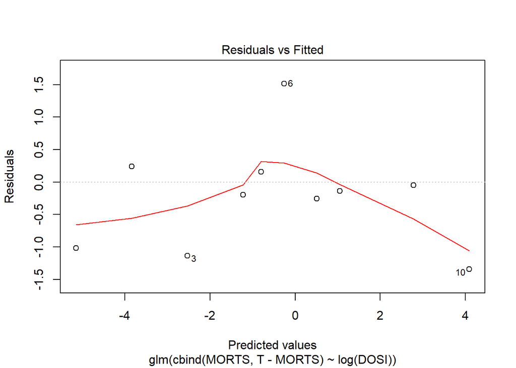

```r
plot(m2,1)
```

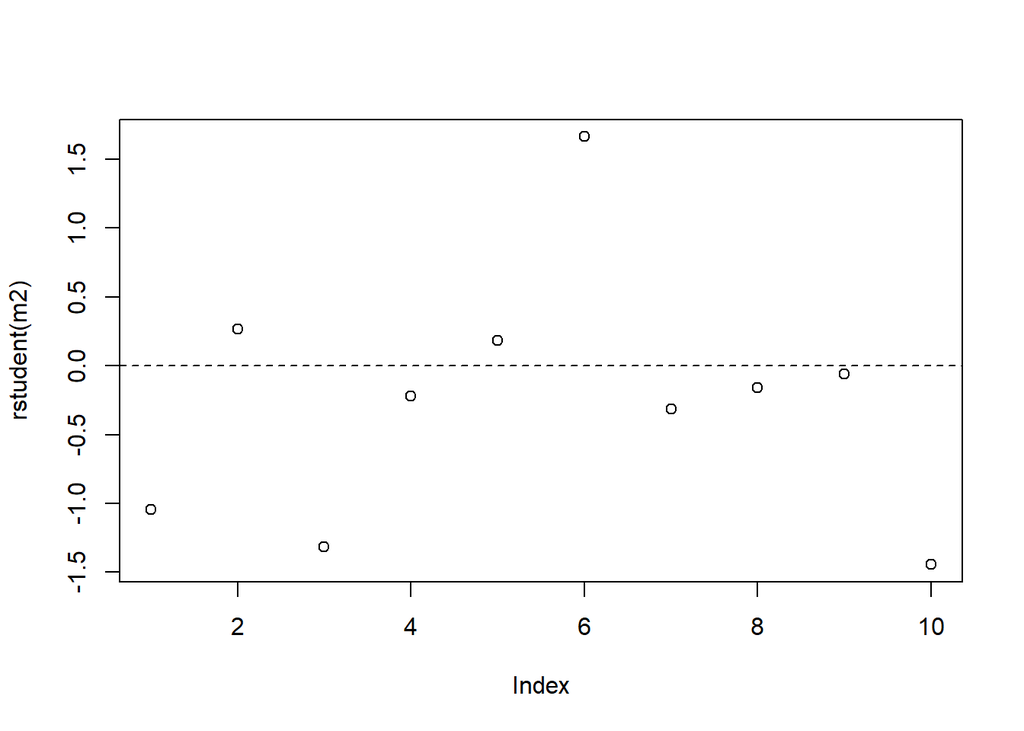

```r
plot(rstudent(m2))
abline(h=c(-2,0,2),lt=2)
```

**c) Proposeu un model lineal generalitzat en el que la probabilitat de morir** $\pi$**, depengui de la dosi seguint la funció** $\pi=1-e^{-a\cdot DOSI^{b}}.$

*i. Estimeu* $\beta_{0}$ *i* $\beta_{1}$*.* $\beta_{0}=0?$*,* $\beta_{1}=0?$

```r
summary(m3<-glm(cbind(MORTS,T-MORTS)~log(DOSI),family=binomial(link="cloglog"),data=dd))
```

```
##
## Call:
## glm(formula = cbind(MORTS, T - MORTS) ~ log(DOSI), family = binomial(link = "cloglog"),
##     data = dd)
##
## Deviance Residuals:
##     Min       1Q   Median       3Q      Max
## -3.1212  -2.0558  -0.3967   1.0123   2.2081
##
## Coefficients:
##             Estimate Std. Error z value Pr(>|z|)
## (Intercept) -3.24683    0.22166  -14.65   <2e-16 ***
## log(DOSI)    1.10722    0.08252   13.42   <2e-16 ***
## ---
## Signif. codes:  0 '***' 0.001 '**' 0.01 '*' 0.05 '.' 0.1 ' ' 1
##
## (Dispersion parameter for binomial family taken to be 1)
##
##     Null deviance: 398.565  on 9  degrees of freedom
## Residual deviance:  32.223  on 8  degrees of freedom
## AIC: 70.224
##
## Number of Fisher Scoring iterations: 10
```

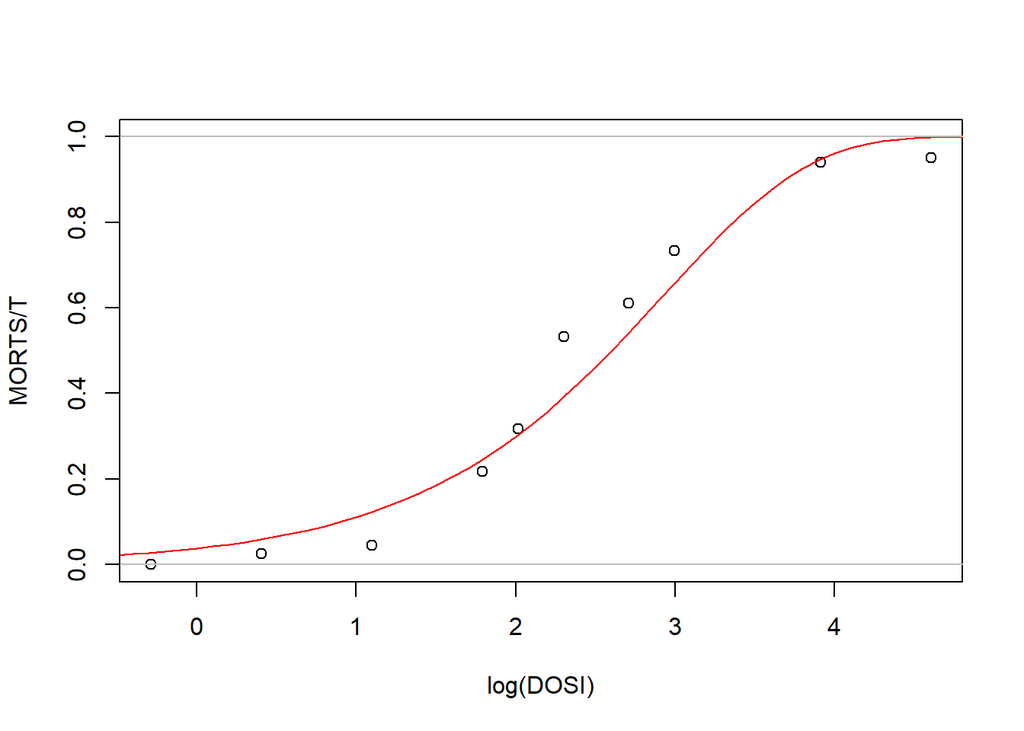

```r
plot(MORTS/T~log(DOSI),dd,ylim=c(0,1))
lines(predict(m3,data.frame(DOSI=dosis),ty="response")~log(dosis),col="red")
abline(h=c(0,1),col="grey")
```

*ii. Mitjançant l’estadístic de Pearson, calculeu el paràmetre de dispersió. Penseu que pot haver-hi sobredispersió?*

```r
c("Pearson"=PS3<-sum(residuals(m3,type="pearson")^2),"G.L."=m3$df.res)
```

```
##  Pearson     G.L.
## 72.87789  8.00000
```

```r
c("Par.disp"=PS3/m3$df.res,"p.valor"=2*min(pchisq(PS3,m3$df.res),1-pchisq(PS3,m3$df.res)))
```

```
##     Par.disp      p.valor
## 9.109736e+00 2.621681e-12
```

*Sí hi ha sobre-dispersió.*

*iii. Amb la gràfica de residuals front predits, dieu si us sembla que la funció ajusta bé.*

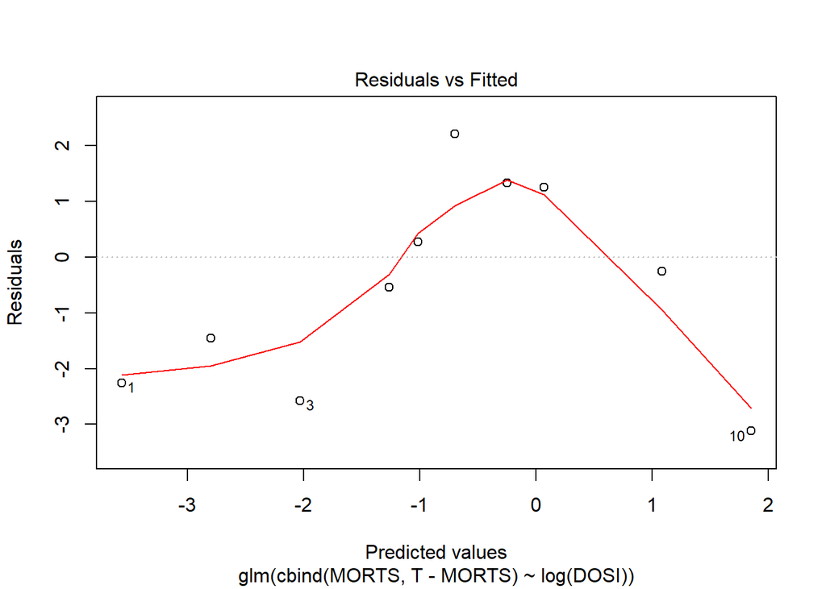

```r
plot(m3,1)
```

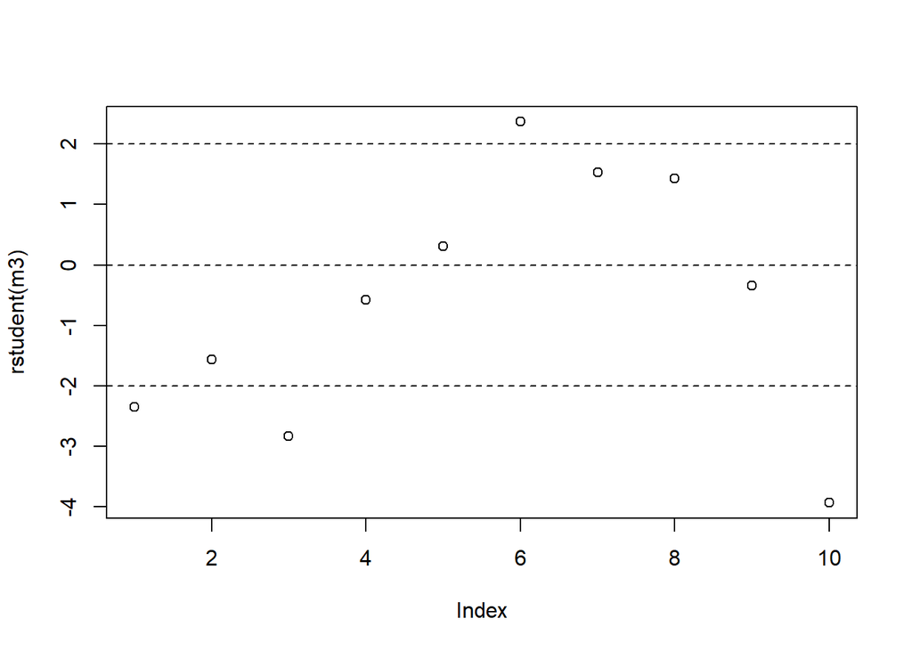

```r
plot(rstudent(m3))
abline(h=c(-2,0,2),lt=2)
```

**d) Proposeu un model lineal generalitzat en el que la probabilitat de morir** $\pi$**, depengui de la dosi seguint la funció** $\pi=e^{-a\cdot DOSI^{b}}.$

*i. Estimeu* $\beta_{0}$ *i* $\beta_{1}$*.* $\beta_{0}=0?$*,* $\beta_{1}=0?$

```r
summary(m4<-glm(cbind(T-MORTS,MORTS)~log(DOSI),family=binomial(link="cloglog"),data=dd))
```

```
##
## Call:
## glm(formula = cbind(T - MORTS, MORTS) ~ log(DOSI), family = binomial(link = "cloglog"),
##     data = dd)
##
## Deviance Residuals:
##     Min       1Q   Median       3Q      Max
## -2.1823  -0.7441  -0.1079   0.7235   1.0918
##
## Coefficients:
##             Estimate Std. Error z value Pr(>|z|)
## (Intercept)  2.18687    0.18479   11.83   <2e-16 ***
## log(DOSI)   -1.08306    0.08557  -12.66   <2e-16 ***
## ---
## Signif. codes:  0 '***' 0.001 '**' 0.01 '*' 0.05 '.' 0.1 ' ' 1
##
## (Dispersion parameter for binomial family taken to be 1)
##
##     Null deviance: 398.565  on 9  degrees of freedom
## Residual deviance:  10.741  on 8  degrees of freedom
## AIC: 48.742
##
## Number of Fisher Scoring iterations: 6
```

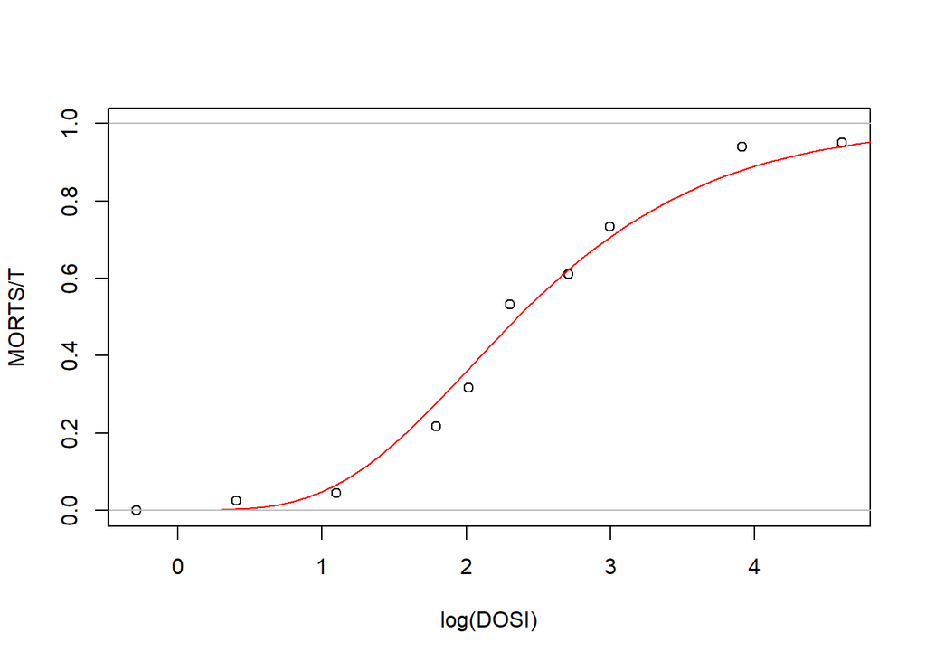

```r
plot(MORTS/T~log(DOSI),dd,ylim=c(0,1))
lines(1-predict(m4,data.frame(DOSI=dosis),ty="response")~log(dosis),col="red")
abline(h=c(0,1),col="grey")
```

*ii. Mitjançant l’estadístic de Pearson, calculeu el paràmetre de dispersió. Penseu que pot haver-hi sobredispersió?*

```r
c("Pearson"=PS4<-sum(residuals(m4,type="pearson")^2),"G.L."=m4$df.res)
```

```
##  Pearson     G.L.
## 17.33214  8.00000
```

```r
c("Par.disp"=PS4/m4$df.res,"p.valor"=2*min(pchisq(PS4,m4$df.res),1-pchisq(PS4,m4$df.res)))
```

```
##   Par.disp    p.valor
## 2.16651736 0.05366098
```

*iii. Amb la gràfica de residuals front predits, dieu si us sembla que la funció ajusta bé.*

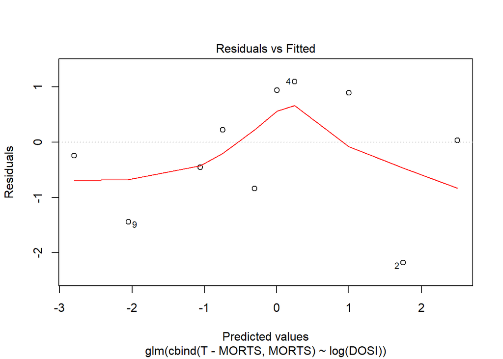

```r
plot(m4,1)
```

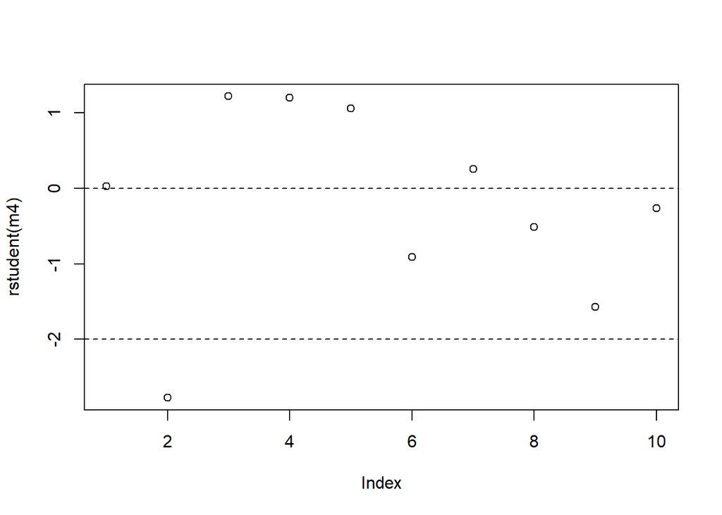

```r
plot(rstudent(m4))
abline(h=c(-2,0,2),lt=2)
```

**d) Dels tres models anteriors quin us sembla més adequat? per què?**

```r
rbind("Deviancies"=c("probit"=m1$deviance,"logit"=m2$deviance,"cloglog"=m3$deviance,"loglog"=m4$deviance),
     "Par.disp.Dev"=c(m1$deviance/m1$df.residual,m2$deviance/m2$df.residual,m3$deviance/m3$df.residual,m4$deviance/m4$df.residual),
     "Pearson"=c(PS1,PS2,PS3,PS4),
     "Par.disp.P"=c(PS1/m1$df.residual,PS2/m2$df.residual,PS3/m3$df.residual,PS4/m4$df.residual),
     "logLik"=c(logLik(m1),logLik(m2),logLik(m3),logLik(m4)),
     "AIC"=c(AIC(m1),AIC(m2),AIC(m3),AIC(m4)),
     "Dif.Dev."=c(m1$null.deviance-m1$deviance,m2$null.deviance-m2$deviance,m3$null.deviance-m3$deviance,
                  m4$null.deviance-m4$deviance),
     "R2"=c(1-m1$deviance/m1$null.deviance,1-m2$deviance/m2$null.deviance,
            1-m3$deviance/m3$null.deviance,1-m4$deviance/m4$null.deviance))
```

```
##                   probit       logit     cloglog      loglog
## Deviancies     7.6834366   6.6528268  32.2233805  10.7407930
## Par.disp.Dev   0.9604296   0.8316033   4.0279226   1.3425991
## Pearson        9.4390029   6.9654792  72.8778902  17.3321389
## Par.disp.P     1.1798754   0.8706849   9.1097363   2.1665174
## logLik       -20.8420779 -20.3267730 -33.1120499 -22.3707561
## AIC           45.6841559  44.6535460  70.2240997  48.7415123
## Dif.Dev.     390.8811438 391.9117537 366.3412000 387.8237874
## R2             0.9807222   0.9833080   0.9191514   0.9730513
```